# Lab 3: Gettin’ Hippy wit it

Author

Cameron White

#### Setup

```r
library(tidyverse)
library(here)
#library(naniar)
```

#### Data Basics

```r
hip <- read_csv(
  here::here("supporting_artifacts",
    "Labs",
    "Lab 3",
    "hiphop.csv"))
```

###### 3. The missing values were in the social network variables were replaced by mean values. This is beneficial because adding the mean value won’t impact a major summary statistic, the mean. On the other hand it likely over or underestimated the true value. It also is an issue that it introduces non-integer values into a column that is counting people.

###### There also seems to be missing population data for 6 indivduals in the ‘county’ and ‘city’ columns that has been substituted with zeroes.

#### Cleaning the Dataset (failed)

```r
hop <- tibble(hip)

#colnames(hop)

#hop_move <- hop |>
  #select(asianMove : whiteMove) |>
  #floor()

#hop_new <- hop |>
  #select(-asianMove:-whiteMove)

#biggie <- merge(hop_new, hop_move)

#Didn't work, the merge function was a huge memory hog and used up all 32gb of my RAM.
```

#### Clean the Data: Rounding down values

```r
# hop$asianMove <- hop$asianMove |>
#   floor()
# hop$blackMove <- hop$blackMove |>
#   floor()
# hop$hispanicMove <- hop$hispanicMove |>
#   floor()
# hop$nativeMove <- hop$nativeMove |>
#   floor()
# hop$SAAMEMove <- hop$SAAMEMove |>
#   floor()
# hop$whiteMove <- hop$whiteMove |>
#   floor()

#revised code:

hop <- hop |>
  mutate(
    across(asianMove:whiteMove, ~floor(.)))
```

#### Cleaning the Dataset vol. 3 (failed)

```r
# hop |>
#   replace_with_na((
#     replace = list(
#       city = 0,
#     county = 0)))
```

#### Counting

```r
count <- unique(hop$word)

#revised code:
count2 <- hop |>
  distinct(word) |>
  select(word)
```

###### 5. There are 64 unique AAE words that were studied in the dataset.

#### Ethnicity

```r
hop <- hop |>
  mutate(
    ethnic_dicot =
      ifelse(ethnic != "white",
      "non-white", "white"))
```

#### Demographics (and some more cleaning)

```r
hop_demo <- hop |>
  distinct(
    subj, sex,
    .keep_all = TRUE) |>
  select(
    subj,
    sex,
    ethnic,
    ethnic_dicot,
    age)

# hop_demo$sex <- as.factor(
#   hop_demo$sex)
#
# hop_demo$ethnic <- as.factor(
#   hop_demo$ethnic)
#
# hop_demo$ethnic_dicot <- as.factor(
#   hop_demo$ethnic_dicot)


#revised code:
hop_demo <- hop_demo |>
  mutate(
    across(c("sex", "ethnic", "ethnic_dicot"), ~as.factor(.)))

summary(hop_demo)
```

```
     subj               sex           ethnic       ethnic_dicot      age
 Length:168         Female:117   white   :135   non-white: 33   Min.   :16.00
 Class :character   Male  : 51   asian   : 19   white    :135   1st Qu.:18.00
 Mode  :character                african :  5                   Median :19.00
                                 hispanic:  3                   Mean   :20.02
                                 indian  :  2                   3rd Qu.:20.00
                                 biracial:  1                   Max.   :48.00
                                 (Other) :  3
```

###### Paring the dataset down to the demographic variables shows that the population sample has larger concentrations of certain indivduals. There are about twice as many female students than male, and 80% of the sample are white. Unurprisingly, the ages closely follow usual college student ages of 18-22, though there are outliers at 16 and 48.

#### Plotting

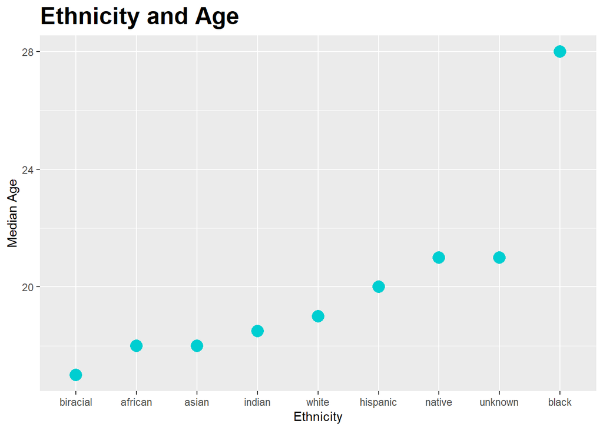

```r
demo_ethnic_age <- hop_demo |>
  group_by(ethnic) |>
  summarize(
    median_age = median(age))

demo_ethnic_age %>%
  ggplot(mapping = aes(
    x = fct_reorder(
      ethnic, median_age),
    y = median_age,
    size = 5)) +
  theme(legend.position = "none") +
  labs(x = "Ethnicity") +
  labs(y = "Median Age") +
  ggtitle("Ethnicity and Age") +
  theme(
    plot.title=element_text(
      family='',
      face='bold',
      colour='black',
      size=20),
    plot.title.position = "panel") +
  geom_point(color = "darkturquoise")
```

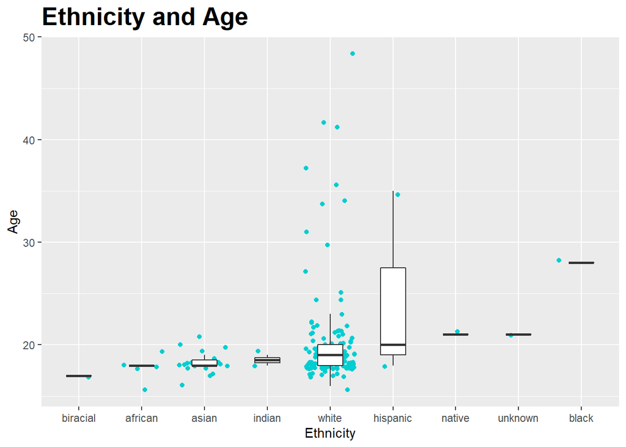

```r
hop_demo %>%
  ggplot(mapping = aes(
    x = fct_reorder(
      ethnic, age),
    y = age)) +
  theme(legend.position = "none") +
  labs(x = "Ethnicity") +
  labs(y = "Age") +
  ggtitle("Ethnicity and Age") +
  theme(
    plot.title=element_text(
      family='',
      face='bold',
      colour='black',
      size=20),
    plot.title.position = "panel") +
  geom_jitter(color = "darkturquoise") +
  geom_boxplot(
    outlier.shape = NA,
    width = 0.4)
```

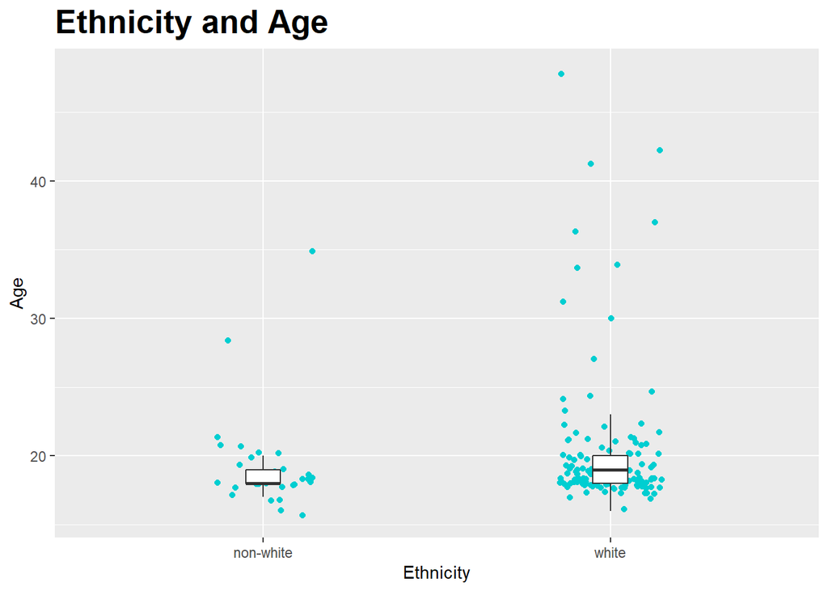

```r
hop_demo %>%
  ggplot(mapping = aes(
    x = ethnic_dicot,
    y = age)) +
  theme(legend.position = "none") +
  labs(x = "Ethnicity") +
  labs(y = "Age") +
  ggtitle("Ethnicity and Age") +
  theme(
    plot.title=element_text(
      family='',
      face='bold',
      colour='black',
      size=20),
    plot.title.position = "panel") +
  geom_jitter(
    color = "darkturquoise",
    width = 0.15) +
  geom_boxplot(
    outlier.shape = NA,
    width = 0.1)
```

#### Young Age Familiarity

```r
YB <- hop |>
  filter(age<20) |>
  distinct(subj)

hop |>
  filter(age<20) |>
  select(word, familiarity) |>
  group_by(word) |>
  summarize(fam = median(familiarity)) |>
  slice_max(order_by = fam)

hop |>
  filter(age<20) |>
  select(word, familiarity) |>
  group_by(word) |>
  summarize(fam = median(familiarity)) |>
  slice_min(order_by = fam)
```

[output not shown]

###### Among the 118 participants under the age of 20, ‘boo’, ‘feel me’, ‘hella’, and ‘off the hook’ are the most commonly known phrases. Of the 64 words in total, 54 of them had a median familiarity score of ‘1’. I’m personally suprised ‘make it rain’ and ‘chedda’ weren’t at the top as well, those are pretty old phrases, especially cheddar equaling money.

#### Non-White women familiarity

```r
# # NWW <- hop |>
#   filter(ethnic_dicot == 'non-white') |>
#   filter(sex == 'Female')
# unique(NWW$subj)
#
# hop |>
#   filter(ethnic_dicot == 'non-white') |>
#   filter(sex == 'Female') |>
#   select(word, familiarity) |>
#   group_by(word) |>
#   summarize(fam = median(familiarity)) |>
#   slice_max(order_by = fam)
#
# hop |>
#   filter(ethnic_dicot == 'non-white') |>
#   filter(sex == 'Female') |>
#   select(word, familiarity) |>
#   group_by(word) |>
#   summarize(fam = median(familiarity)) |>
#   slice_min(order_by = fam)


#Revised code:
NWW <- hop |>
  filter(ethnic_dicot == 'non-white',
         sex == 'Female') |>
  distinct(subj)


hop |>
  filter(ethnic_dicot == 'non-white',
         sex == 'Female') |>
  select(word, familiarity) |>
  group_by(word) |>
  summarize(
    fam = median(familiarity)) |>
  slice_max(order_by = fam)

hop |>
  filter(ethnic_dicot == 'non-white',
         sex == 'Female') |>
  select(word, familiarity) |>
  group_by(word) |>
  summarize(fam = median(familiarity)) |>
  slice_min(order_by = fam)
```

[output not shown]

###### Of the 26 participants who are non-white and female, ‘boo’, ‘feel me’, and ‘off the hook’, were again top phrases.

#### White Men above 30 Familiarity

```r
# W.M.30 <- hop |>
#   filter(ethnic_dicot == 'white') |>
#   filter(sex == 'Male') |>
#   filter(age > 30)
# unique(W.M.30$subj)
#
# hop |>
#   filter(ethnic_dicot == 'white') |>
#   filter(sex == 'Male') |>
#   filter(age > 30) |>
#   select(word, familiarity) |>
#   group_by(word) |>
#   summarize(fam = median(familiarity)) |>
#   slice_max(order_by = fam)


#Revised code:
W.M.30 <- hop |>
  filter(ethnic_dicot == 'white',
         sex == 'Male',
         age > 30) |>
  distinct(subj)

hop |>
  filter(ethnic_dicot == 'white',
         sex == 'Male',
         age > 30) |>
  select(word, familiarity) |>
  group_by(word) |>
  summarize(fam = median(familiarity)) |>
  slice_max(order_by = fam)
```

[output not shown]

###### Of the 5 white men over the age of 30, they were most familiar with ‘off the hook’, and ‘feel me’. That is where the commonalities end, the other more familiar ones are ‘5-0’, ‘A-town’, and ‘hard’. A brief moment looking up the history of the term ‘5.0’ is another reminder of my privilege of the conditions of my birth.

#### Task: Filtering Bieber

```r
# hop |>
#   filter(ethnic_dicot == 'white') |>
#   filter(sex == 'Male') |>
#   filter(age >= 17) |>
#   filter(age <= 23) |>
#   filter(city >= 10000) |>
#   filter(city <= 60000) |>
#   filter(bieber == 5)


#Revised code:
hop |>
  filter(ethnic_dicot == 'white',
         sex == 'Male',
         age >= 17,
         age <= 23,
         city >= 10000,
         city <= 60000) |>
  slice_max(bieber) |>
  distinct(subj)
```

[output not shown]

###### My guess is that ‘The Biebs’ is participant ‘p17’, though I was surprised that I had to lower the bieber filter to a score of 5 instead of 6…